# FordGoBike Data Trends Visualization

## Investigation Overview

> Ford GoBike is a regional public bicycle sharing system in the San Francisco Bay Area, California. Beginning operation in August 2013 as Bay Area Bike Share, we will investigate The duration of Biking, the distribution of trips over periods, and the user's traits.

## Dataset Overview

> the data set I'm using today is for February 2019, which covers info about trips taken by service members, their types, their age, their gender, stations of starting and ending trips, duration of trips, etc.

```python
# import all packages and set plots to be embedded inline
import numpy as np
import pandas as pd
import matplotlib.pyplot as plt
import seaborn as sb

%matplotlib inline

# suppress warnings from final output
import warnings
warnings.simplefilter("ignore")
```

```python
# load in the dataset into a pandas dataframe
df = pd.read_csv('clean_GoBike.csv')
df.info()
```

```
<class 'pandas.core.frame.DataFrame'>
RangeIndex: 174749 entries, 0 to 174748
Data columns (total 20 columns):
 #   Column                   Non-Null Count   Dtype
---  ------                   --------------   -----
 0   duration_sec             174749 non-null  int64
 1   start_time               174749 non-null  object
 2   end_time                 174749 non-null  object
 3   start_station_id         174749 non-null  float64
 4   start_station_name       174749 non-null  object
 5   start_station_latitude   174749 non-null  float64
 6   start_station_longitude  174749 non-null  float64
 7   end_station_id           174749 non-null  float64
 8   end_station_name         174749 non-null  object
 9   end_station_latitude     174749 non-null  float64
 10  end_station_longitude    174749 non-null  float64
 11  bike_id                  174749 non-null  int64
 12  user_type                174749 non-null  object
 13  member_birth_year        174749 non-null  float64
 14  member_gender            174749 non-null  object
 15  bike_share_for_all_trip  174749 non-null  object
 16  member_age               174749 non-null  float64
 17  start_DayofWeek          174749 non-null  object
 18  start_hour               174749 non-null  int64
 19  duration_min             174749 non-null  float64
dtypes: float64(9), int64(3), object(8)
memory usage: 26.7+ MB
```

```python
weekdays = ['Mon','Tue','Wed','Thu','Fri', 'Sat', 'Sun']
ordered_weekdays = pd.api.types.CategoricalDtype(ordered = True, categories = weekdays)
df['start_DayofWeek'] = df['start_DayofWeek'].astype(ordered_weekdays)
```

```python
df.info()
```

```
<class 'pandas.core.frame.DataFrame'>
RangeIndex: 174749 entries, 0 to 174748
Data columns (total 20 columns):
 #   Column                   Non-Null Count   Dtype
---  ------                   --------------   -----
 0   duration_sec             174749 non-null  int64
 1   start_time               174749 non-null  object
 2   end_time                 174749 non-null  object
 3   start_station_id         174749 non-null  float64
 4   start_station_name       174749 non-null  object
 5   start_station_latitude   174749 non-null  float64
 6   start_station_longitude  174749 non-null  float64
 7   end_station_id           174749 non-null  float64
 8   end_station_name         174749 non-null  object
 9   end_station_latitude     174749 non-null  float64
 10  end_station_longitude    174749 non-null  float64
 11  bike_id                  174749 non-null  int64
 12  user_type                174749 non-null  object
 13  member_birth_year        174749 non-null  float64
 14  member_gender            174749 non-null  object
 15  bike_share_for_all_trip  174749 non-null  object
 16  member_age               174749 non-null  float64
 17  start_DayofWeek          174749 non-null  category
 18  start_hour               174749 non-null  int64
 19  duration_min             174749 non-null  float64
dtypes: category(1), float64(9), int64(3), object(7)
memory usage: 25.5+ MB
```

## Histogram of trip duration in minutes

### Remarks

- Most of the trips are below 15 min
- The avrage trip is 11.7 min
- The longest trip was 1409 min (23 hours 29 minutes)
- The shortest trip was 1 min

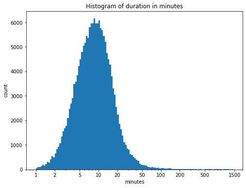

```python
#Closer look at Histogram of duration in minutes
log_binsize = 0.025
bins = 10 ** np.arange(0, np.log10(df.duration_min.max())+log_binsize, log_binsize)
plt.figure(figsize=[8, 6])
plt.hist(data = df, x = 'duration_min', bins = bins)
plt.xscale('log')
plt.xticks([1, 2, 5, 10, 20, 50, 100, 200, 500, 1500], [1, 2, 5, 10, 20, 50, 100, 200, 500, 1500])
plt.title("Histogram of duration in minutes")
plt.xlabel('minutes')
plt.ylabel("count");
```

## Trip Duration across different weekdays and hours¶

### Remarks

- riders on Sunday and Saturday on average have the longest trip duration
- riders on 2 AM and 3 AM on average have the longest trip duration
- Sunday 3 AM have the longest trip average

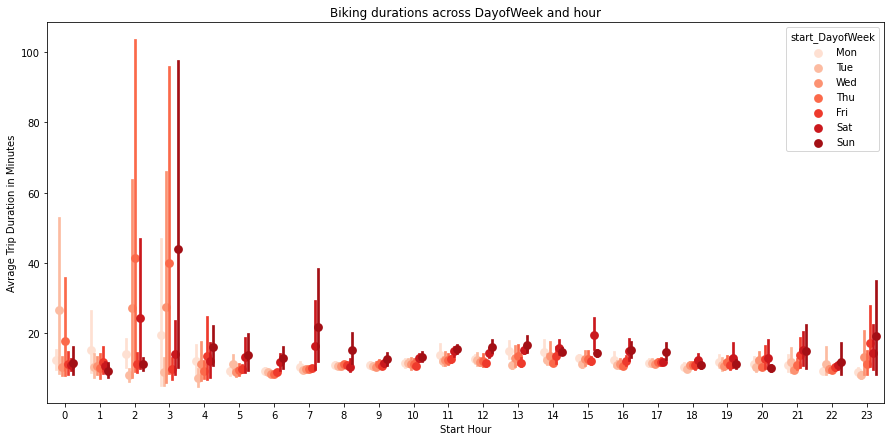

```python
#How the avrage trip duration vary in each day and hour
plt.figure(figsize=[15,7])
sb.pointplot(data = df, x = 'start_hour', y = 'duration_min', hue = 'start_DayofWeek',
             dodge = 0.5, linestyles = "",palette='Reds')

plt.title('Biking durations across DayofWeek and hour')
plt.xlabel('Start Hour');
plt.ylabel('Avrage Trip Duration in Minutes');
```

## Trip duration across different ages scatterplot

### Remarks

- Younger riders (18 to 50) tend to have longer trips
- trip duration start to drop after the age 50

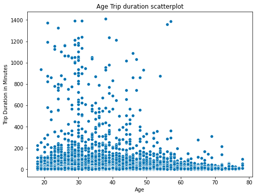

```python
#Age duration scatterplot
blu = sb.color_palette('colorblind')[0]
plt.rcParams['figure.figsize'] = 8, 6
sb.scatterplot(data=df, x='member_age', y='duration_min', color=blu);
plt.title("Age Trip duration scatterplot")
plt.xlabel('Age');
plt.ylabel('Trip Duration in Minutes');
```